# Inhomogeneity Correction

1/20/2017

## Inhomogeneity correction

- Scans can have nonuniform intensities throughout the brain
- Usually low frequency - smooth over the brain (assumed)
- Referred to as bias, bias field, or inhomogeneity

## Kirby21 Data

Let's read in the T1 image from a kirby21 data set for visit 1:

```r
library(kirby21.t1)
library(neurobase)
t1_fname = get_t1_filenames(visit = 1, id = 505)
t1 = readnii(t1_fname)
```

## Kirby21 Data

We see the head and the neck are images in this T1 (orientation is not RPI):

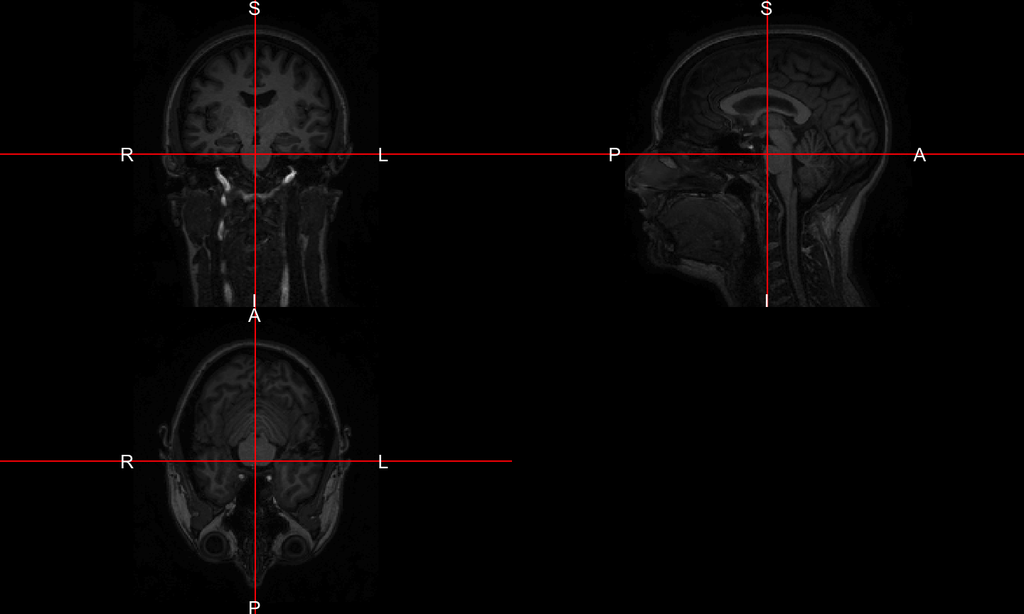

```r
ortho2(t1)
```

## N4 Inhomogeneity Correction

We will use N4: Improved N3 Bias Correction (Tustison et al. 2010).

The model assumed in the N4 is: \[ v(x) = u(x)f(x) + n(x) \]

where \(v\) is the given image, \(u\) is the uncorrupted image, \(f\) is the bias field, and \(n\) is the noise (assumed to be independent and Gaussian) and \(x\) is a location in the image.

## N4 Inhomogeneity Correction

The data is log-transformed and assuming a noise-free scenario, we have:

\[ log(v(x)) = log(u(x)) + log( f(x) ) \]

- N4 uses a B-spline approximation of the bias field
- It iterates until a convergence criteria is met
  - when the updated bias field is the same as the last iteration
- It outputs the data back in the original units (not log-transformed)

## Bias Field Correction

Here we will use the `bias_correct` function in `extrantsr`, which calls `n4BiasFieldCorrection` from `ANTsR`.

You can pass in the image:

```r
library(extrantsr)
bc_t1 = bias_correct(file = t1, correction = "N4")
```

or the filename:

```r
bc_t1 = bias_correct(file = t1_fname, correction = "N4")
```

## Visualizing Bias Field Correction

We can try visualize the bias field. Here we take the ratio of the images and overlay it on the original image:

```r
ratio = t1 / bc_t1; ortho2(t1, ratio)
```

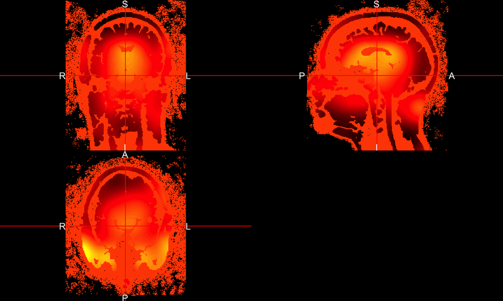

## Visualizing Bias Field Correction

Here we would like to change the colors to something more descriptive. Here we will use a diverging palette and map colors to the quantiles of the ratio image:

```r
library(scales)
q = quantile(ratio[ ratio != 0], probs = seq(0, 1, by = 0.1), na.rm = TRUE)
q = unique(q)
# get a diverging gradient palette
fcol = scales::div_gradient_pal(low = "blue", mid = "yellow", high = "red")
colors =  scales::alpha(fcol(seq(0,1, length = length(q) - 1)), 0.5)
```

## Visualizing Bias Field Correction

Now we put those breaks into `ortho2` to plot it:

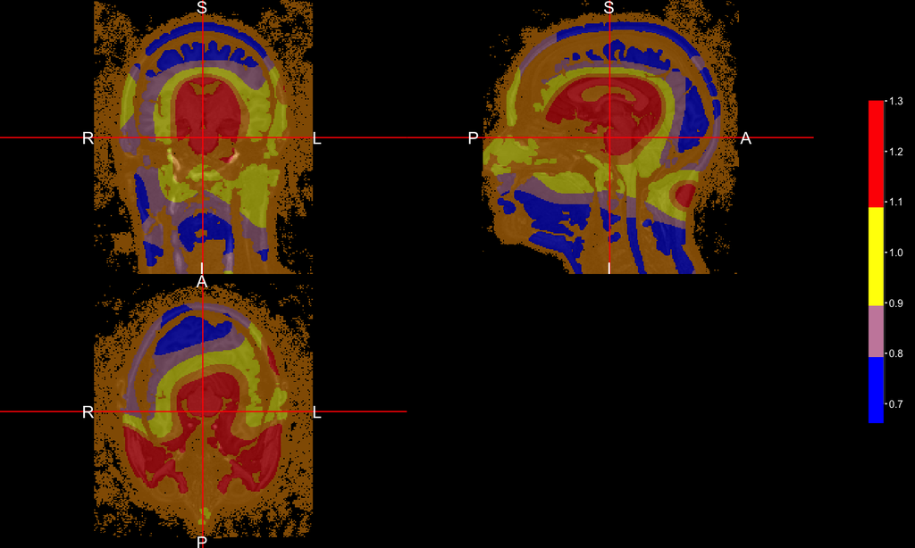

```r
ortho2(t1, ratio, col.y = colors, ybreaks = q, ycolorbar = TRUE)
```

## Histogram of Ratio Values

The majority of voxels have a ratio of \(1\) because `n4BiasFieldCorrection` does some implicit masking using `ANTsR::getMask`.

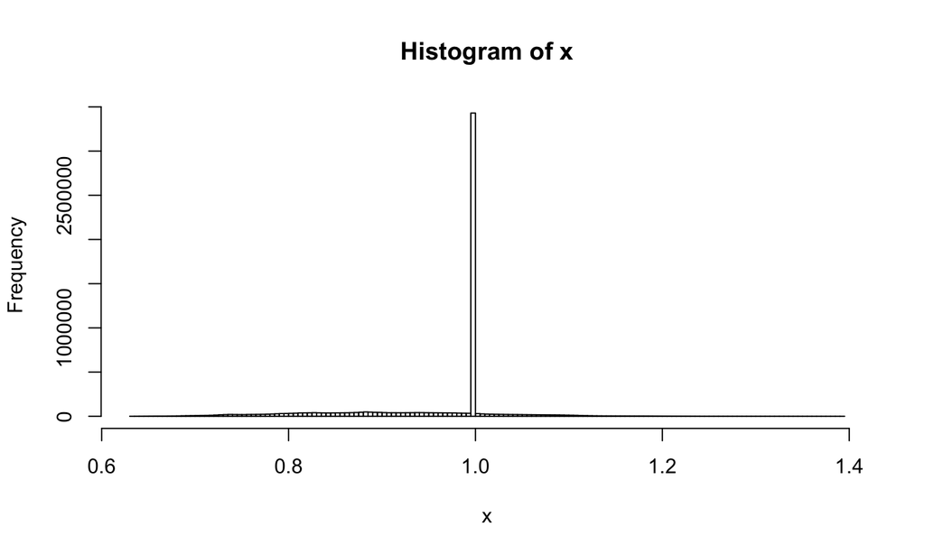

```r
hist(ratio, breaks = 200)
```

## Visualizing Bias Field Correction

Removing these, we can see what the distribution of ratios look like:

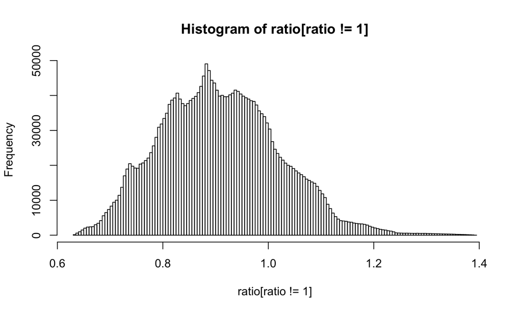

```r
hist(ratio[ratio != 1], breaks = 200)
```

## Visualizing Bias Field Correction

Here we make a `data.frame` of the indices with the values and cut the z-dimension into the bottom, middle and top:

```r
df = which(ratio != 1, arr.ind = TRUE)
df = cbind(df, value = ratio[df])
df = data.frame(df, stringsAsFactors = FALSE)
df$location = cut(df$dim3, breaks = c(0, 86, 172, 256),
                  labels = c("bottom", "middle", "top"))
```

```
##   dim1 dim2 dim3     value location
## 1   81   96    1 0.7327191   bottom
## 2   82   96    1 0.7335099   bottom
## 3   83   96    1 0.7342617   bottom
## 4   84   96    1 0.7349642   bottom
## 5   85   96    1 0.7356078   bottom
## 6   86   96    1 0.7361845   bottom
```

## Visualizing Bias Field Correction

Let's plot these with a density plot for each different location:

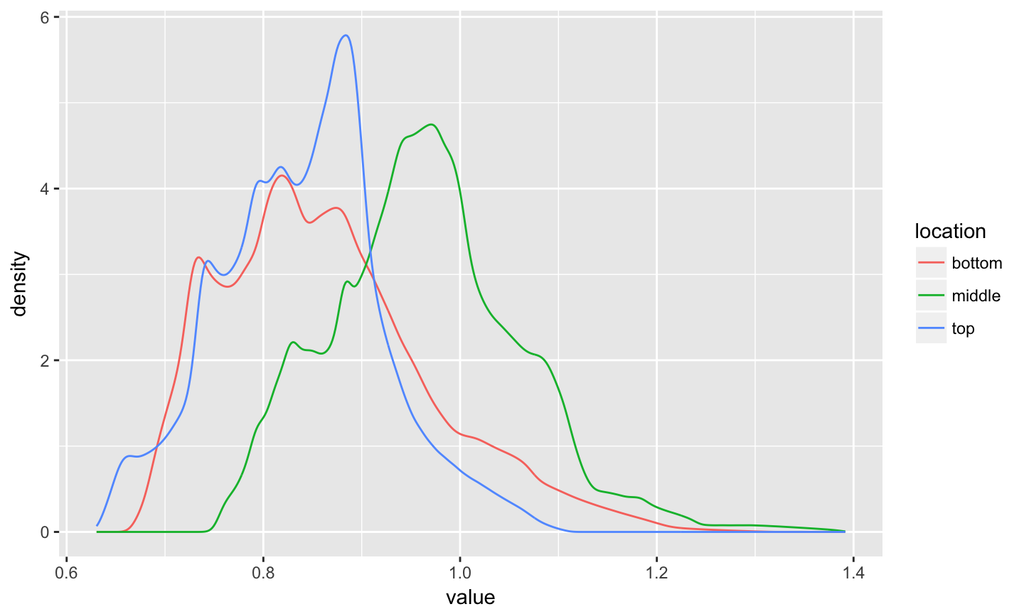

```r
ggplot(df, aes(x = value, colour = location)) + geom_line(stat = "density")
```

## Conclusions

- Inhomogeneity correction is one of the first steps of most structural MRI pipelines
- Inhomogeneity can cause problems for other methods/segmentation
- Corrections try to make tissues of the same class to have similar intensities
- You may also want to run corrections after skull stripping on the brain only
  - we will do this in the brain extraction lecture
  - correction before skull-stripping may be necessary and can improve after correction

## References

Tustison, Nicholas J., Brian B. Avants, Philip A. Cook, Yuanjie Zheng, Alexander Egan, Paul A. Yushkevich, and James C. Gee. 2010. “N4ITK: Improved N3 Bias Correction.” *IEEE Transactions on Medical Imaging* 29 (6): 1310–20. doi:10.1109/TMI.2010.2046908.